# UNICEF Child Labour & Life Expectancy Analysis

## Loading Required Libraries:

```r
library(dplyr)
library(ggplot2)
library(sf)
library(leaflet)
```

## Top 10 Countries By Child Labour Threshold:

A bar chart is created to show the top 10 countries by child labour threshold and is attached below. It can be seen that the child labour threshold is highest for Burkina Faso which stands at a whopping 45.23%. The country that follows the Burkina Faso in terms of child labour threshold is the Somalia with 42.5% child labour threshold. Moreover, it can be observed that Cameroon, Togo and Mali are the countries which comes at third, fourth and fifth number with a child labour threshold percentage of 34.07%, 33.97% and 30.67% respectively.

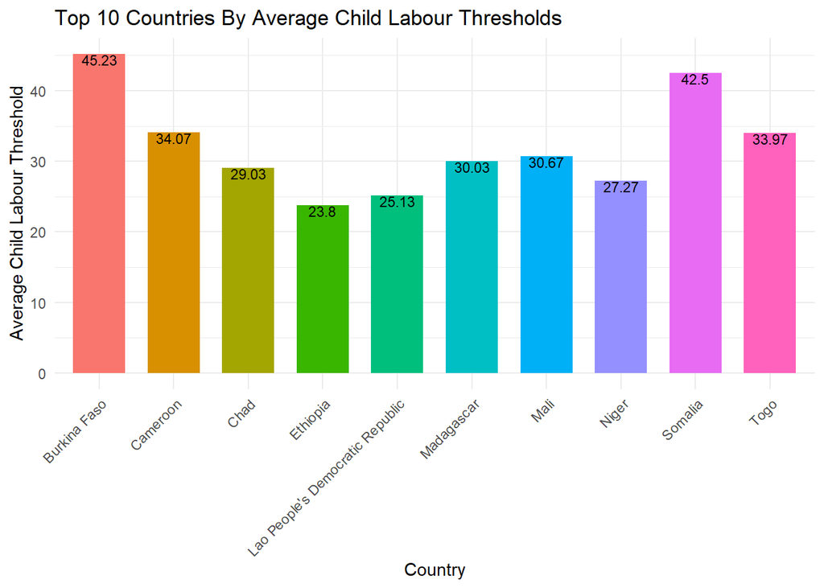

```r
data <- read.csv("unicef_indicator_1.csv")

data_subset <- data %>%
  select(country, alpha_2_code, time_period, indicator, obs_value, sex,
         unit_of_measure)

res <- data_subset %>%
  group_by(country) %>%
  summarise(Avg_Value = round(mean(obs_value, na.rm = T), 2)) %>%
  arrange(-Avg_Value) %>%
  head(10)

# Create the bar chart
ggplot(res, aes(x = country, y = Avg_Value, fill = country)) +
  geom_bar(stat = "identity", width = 0.7) +
  geom_text(aes(label = Avg_Value), vjust = 1.0, color = "black", size = 3) +
  labs(title = "Top 10 Countries By Average Child Labour Thresholds",
       x = "Country",
       y = "Average Child Labour Threshold") +
  theme_minimal() +
  theme(axis.text.x = element_text(angle = 45, hjust = 1)) +
  guides(fill = FALSE)
```

## Relationship Between Time & Child Labour Threshold:

A scatter chart is created to see if there is any relationship between child labour threshold and year or time. A scatter plot with regression line fitted to it is obtained and is attached below. It can be seen that the regression line is flat which shows that there is no relationship between time period and child labour threshold.

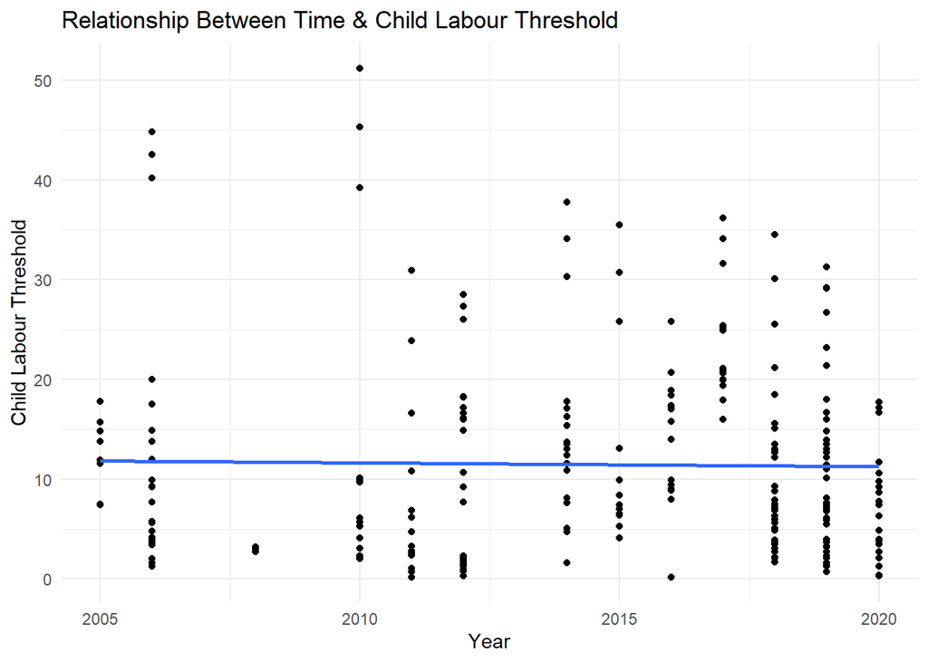

```r
# Create the scatter plot with regression line
ggplot(data_subset, aes(x = time_period,
                        y = obs_value)) +
  geom_point() +  # Add points for the scatter plot
  geom_smooth(method = "lm", se = FALSE) +  # Add regression line
  labs(title = "Relationship Between Time & Child Labour Threshold",
       x = "Year", y = "Child Labour Threshold")+
  theme_minimal()
```

## Trend of Life Expectancy:

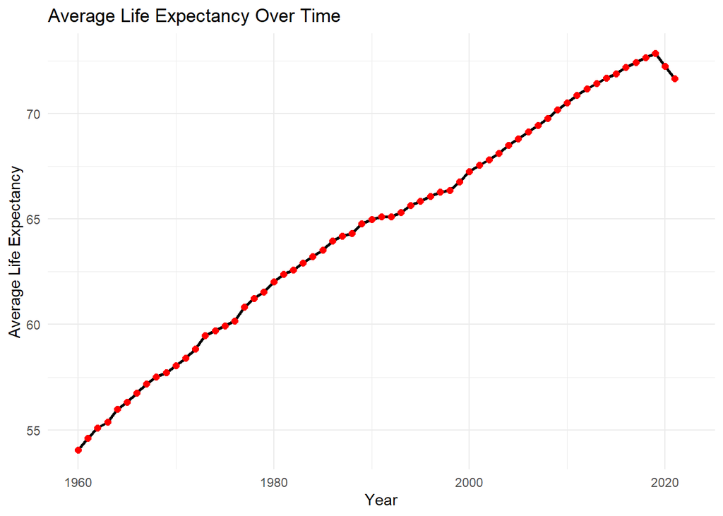

```r
data <- read.csv("unicef_metadata.csv")

res <- data %>%
  group_by(year) %>%
  summarise(Life_Expectancy = mean(Life.expectancy.at.birth..total..years.,
                                   na.rm = T))

# Line chart with markers
ggplot(res, aes(x = year, y = Life_Expectancy, group = 1)) +
  geom_line(lwd = 1) +          # Add a line
  geom_point(color = "red", size = 2) +  # Add points
  labs(title = "Average Life Expectancy Over Time",
       x = "Year",
       y = "Average Life Expectancy") +
  theme_minimal()
```

## Life Expectancy By Country:

Finally, a world map is created which is attached below. The map shows the average life expectancy by each country. The values are not shown as a tooltip in this case because of too much overlapping. The top 3 countries with highest average life expectancy are Cayman Islands, Liechtenstein and Faroe Islands with values of 82, 80 and 79 years approximately.

```r
res <- data %>%
  group_by(alpha_3_code) %>%
  summarise(Life_Expectancy = mean(Life.expectancy.at.birth..total..years.,
                                   na.rm = T))
names(res)[1] <- "ISO3_CODE"

countries <- giscoR::gisco_get_countries() %>%
  st_centroid()

final <- countries %>%
  inner_join(res, by = "ISO3_CODE")

final <- as.data.frame(final)

# Extract latitude and longitude from the 'geometry' column
final$latitude <- sapply(final$geometry,
                         function(point) st_coordinates(point)[, 2])
final$longitude <- sapply(final$geometry,
                          function(point) st_coordinates(point)[, 1])

# Create a leaflet map
m <- leaflet() %>%
  addTiles() %>%
  setView(lng = 0, lat = 30, zoom = 2)

# Add markers for each country with life expectancy as popup
m <- m %>%
  addCircleMarkers(
    data = final,
    lng = ~latitude,
    lat = ~longitude,
    radius = 5,
    popup = ~paste(NAME_ENGL, "<br>", "Life Expectancy:", Life_Expectancy),
    color = "red",
    fillOpacity = 0.8
  )

# Print the map
m
```

[interactive chart not shown]